# Week 3, Meeting 2

## From last lecture

- finish dictionaries
- Python Standard Library
- Built-ins
- This lecture: a look at higher order functions & classes

# more dictionaries

## The .items() method for dictionaries

- This method returns a *view object* containing key-value pairs as tuples
- A view object is a representation of a dictionary’s keys, values, or items (key-value pairs)
- View objects are dynamic and they automatically reflect changes made to their dictionary of origin

## Examples

- Dictionary
- Iterate
- Filter
- Transform
- Lookup
- Sort

```python
cities = {
    "New York": (40.7128, -74.0060),
    "Los Angeles": (34.0522, -118.2437),
    "Chicago": (41.8781, -87.6298),
    "Houston": (29.7604, -95.3698),
    "Phoenix": (33.4484, -112.0740),
    "Miami": (25.7617, -80.1918),
    "Seattle": (47.6062, -122.3321),
    "Denver": (39.7392, -104.9903),
    "Boston": (42.3601, -71.0589),
    "San Francisco": (37.7749, -122.4194)
}

# check
print(cities)
list(cities.items())
```

```
{'New York': (40.7128, -74.006), 'Los Angeles': (34.0522, -118.2437), 'Chicago': (41.8781, -87.6298), 'Houston': (29.7604, -95.3698), 'Phoenix': (33.4484, -112.074), 'Miami': (25.7617, -80.1918), 'Seattle': (47.6062, -122.3321), 'Denver': (39.7392, -104.9903), 'Boston': (42.3601, -71.0589), 'San Fra…
```

```
[('New York', (40.7128, -74.006)),
 ('Los Angeles', (34.0522, -118.2437)),
 ('Chicago', (41.8781, -87.6298)),
 ('Houston', (29.7604, -95.3698)),
 ('Phoenix', (33.4484, -112.074)),
 ('Miami', (25.7617, -80.1918)),
 ('Seattle', (47.6062, -122.3321)),
 ('Denver', (39.7392, -104.9903)),
 ('Boston', (42.3601, -71.0589)),
 ('San Francisco', (37.7749, -122.4194))]
```

```python
for city, coordinates in cities.items():
    print(f"{city}: Latitude {coordinates[0]}, Longitude {coordinates[1]}")
```

```
New York: Latitude 40.7128, Longitude -74.006
Los Angeles: Latitude 34.0522, Longitude -118.2437
Chicago: Latitude 41.8781, Longitude -87.6298
Houston: Latitude 29.7604, Longitude -95.3698
Phoenix: Latitude 33.4484, Longitude -112.074
Miami: Latitude 25.7617, Longitude -80.1918
Seattle: Latitude 47.6062, Longitude -122.3321
Denver: Latitude 39.7392, Longitude -104.9903
Boston: Latitude 42.3601, Longitude -71.0589
San Francisco: Latitude 37.7749, Longitude -122.4194
```

- Recall list comprehension https://peps.python.org/pep-0202/ part of Python’s syntax
- Dictionary comprehension (https://peps.python.org/pep-0274/) is similar.
- We can use dictionary comprehension to filter
- Syntax is {key: value for key, value in original_dict.items() if condition}

```python
filtered_dict = {cityname: coords for cityname, coords in cities.items() if coords[0] > 40}

for city, coordinates in filtered_dict.items():
    print(f"{city}: Latitude {coordinates[0]}, Longitude {coordinates[1]}")
```

```
New York: Latitude 40.7128, Longitude -74.006
Chicago: Latitude 41.8781, Longitude -87.6298
Seattle: Latitude 47.6062, Longitude -122.3321
Boston: Latitude 42.3601, Longitude -71.0589
```

- Use dictionary comprehension to transform values
- Here, we are just switching longitude and latitude but you could apply virtually any function

```python
cities_switched = {
    cityname: (coords[1],coords[0])
    for cityname, coords in cities.items()
}

for city, coordinates in cities_switched.items():
    print(f"{city}: Longitude {coordinates[0]}, Latitude {coordinates[1]}")
```

```
New York: Longitude -74.006, Latitude 40.7128
Los Angeles: Longitude -118.2437, Latitude 34.0522
Chicago: Longitude -87.6298, Latitude 41.8781
Houston: Longitude -95.3698, Latitude 29.7604
Phoenix: Longitude -112.074, Latitude 33.4484
Miami: Longitude -80.1918, Latitude 25.7617
Seattle: Longitude -122.3321, Latitude 47.6062
Denver: Longitude -104.9903, Latitude 39.7392
Boston: Longitude -71.0589, Latitude 42.3601
San Francisco: Longitude -122.4194, Latitude 37.7749
```

- Suppose our dictionary was enormous (e.g., every city in the world)
- Dictionaries can perform fast lookups using the get method

```python
coords = cities.get("Chicago")
if coords:
    print(f"Coordinates: {coords}")
else:
    print("City not found.")
```

```
Coordinates: (41.8781, -87.6298)
```

- Recall last lecture we examined the sorted() with lambda (an anonymous function)
- Lambda helps us to sort a dictionary, in this example, on the latitude in reverse order using a single line of code

```python
sorted_cities = dict(sorted(cities.items(), key=lambda item: item[1][0], reverse=True))

for city, coordinates in sorted_cities.items():
    print(f"{city}: Latitude {coordinates[0]}, Longitude {coordinates[1]}")
```

```
Seattle: Latitude 47.6062, Longitude -122.3321
Boston: Latitude 42.3601, Longitude -71.0589
Chicago: Latitude 41.8781, Longitude -87.6298
New York: Latitude 40.7128, Longitude -74.006
Denver: Latitude 39.7392, Longitude -104.9903
San Francisco: Latitude 37.7749, Longitude -122.4194
Los Angeles: Latitude 34.0522, Longitude -118.2437
Phoenix: Latitude 33.4484, Longitude -112.074
Houston: Latitude 29.7604, Longitude -95.3698
Miami: Latitude 25.7617, Longitude -80.1918
```

## (quick review) Lambda

- lambda is a small anonymous (unnamed) function with a simple syntax
- syntax is *lambda arguments: expression*
- use it when you don’t want to write a full function when a simple one-line operation will do
- So in the previous slide on sorting dictionary values

```
lambda item: item[1][0]
```

instead of building another function and passing arguments to sorted()

```
def get_latitude(item):
    return item[1][0]

dict(sorted(cities.items(), key=get_latitude, reverse=True))
```

## Dictionary Comprehension Takeways

- Syntax {key: value for key, value in original_dict.items() if condition}
- Provides a concise (single line) way to create dictionaries
- Applies an expression to each item in an iterable (like a list, tuple or another dictionary) and can also filtering items based on a condition
- More efficient than a for loop

## Python Standard Library (PSL)

- We have imported modules such as json, csv, math
- We did not separately install them, they are bundled with a Python installation
- While libraries such as NumPy, Pandas, matplotlib etc. supercede much of the PSL
- Some parts of the PSL are worth reviewing

## Basic Data Types and Utilities

- math – Mathematical functions like math.sqrt(), math.pi, math.log()
- random – Generating random numbers, shuffling, and choices (random.randint(), random.choice())
- datetime – Working with dates and times (datetime.datetime.now(), datetime.timedelta)
- time – Time-related functions like sleeping (time.sleep(), time.time())
- sys – System-specific parameters and functions (sys.argv, sys.exit(), sys.stdout)

## File Handling and OS Interaction

- os – Interacting with the operating system (os.listdir(), os.path.join(), os.environ)
- pathlib – Object-oriented file system paths (Path().glob(), Path().exists())
- shutil – File operations like copying and moving (shutil.copy(), shutil.move())

## Data Handling and Processing

- json – Parsing and writing JSON (json.load(), json.dump())
- csv – Reading and writing CSV files (csv.reader(), csv.DictWriter())
- sqlite3 – SQL database (sqlite3.connect(), cursor.execute())

# Quick Recap of Built-Ins

## Built-Ins: Input and Output

- print() – Prints output
- input() – Gets user input
- open() – Opens files for reading and writing

## Built-Ins: Type Conversion

- int() – Converts to an integer
- float() – Converts to a floating-point number
- str() – Converts to a string
- bool() – Converts to a Boolean (True or False)
- list() – Converts to a list
- tuple() – Converts to a tuple
- set() – Converts to a set
- dict() – Converts to a dictionary

## Built-Ins: Iterables and Sequences

- len() – Returns the length of a sequence
- range() – Generates a sequence of numbers
- enumerate() – Returns an iterator with index-value pairs
- zip() – Combines multiple iterables element-wise
- sorted() – Returns a sorted version of an iterable
- reversed() – Returns a reversed iterator
- sum() – Returns the sum of an iterable
- min() – Returns the smallest element in an iterable
- max() – Returns the largest element in an iterable
- any() – Returns True if any element in an iterable is True
- all() – Returns True if all elements in an iterable are True

## Built-Ins: Programming

- lambda - Creates small anonymous functions
- try, except, raise - Handles exceptions

## Built-Ins: Checking

- type() – Returns the type of an object
- isinstance() – Checks if an object is an instance of a class
- id() – Returns the memory address of an object
- hash() – Returns the hash value of an object
- dir() – Lists all attributes of an object
- vars() – Returns the **dict** attribute of an object
- help() – Displays documentation for an object
- del – Deletes an object

## File and I/O Operations

- open() – Opens files for reading/writing
- read() – Reads files
- write() – Writes data to a file
- close() – Closes a file
- with - a keyword, manages resources, e.g., files or network connections, so they are correctly acquired and released, even when there are errors

## Etc.

- chr() – Converts an integer to a character.
- ord() – Converts a character to its Unicode value.
- bin() – Converts an integer to binary.
- hex() – Converts an integer to hexadecimal.
- pow() – Computes power (pow(x, y) is equivalent to x ** y)
- round() – Rounds a floating-point number.
- abs() – Returns the absolute value.
- divmod() – Returns quotient and remainder of division.

# (optional) Nested Functions

## (optional) nested functions

- In the discusssion of LEGB we saw a nested function
- A nested function AKA an inner function, is a function defined inside another function.
- A nested function can access variables from the enclosing function’s scope
- Its variables are hidden from the global scope or other functions. This results in a type of data shielding from misuse or unintended modification.
- It can make the code appear cleaner and tighter because its a grouping of like functions
- Or when you want a function available only to one other function.

## (optional) Nested Example

- The function get_color_value(color_name) is nested inside of def get_rgb_input()

```python
def get_rgb_input():
    """Prompt user for R, G, B values and validate them.
    Write an image file to local drive to see the color
    uses nested function get_color_value()
    """
    def get_color_value(color_name):
        while True:
            try:
                value = int(input(f"Enter value for {color_name} (0-255): "))
                if 0 <= value <= 255:
                    return value
                else:
                    print("Value must be between 0 and 255.")
            except ValueError:
                print("Please enter an integer.")

    r = get_color_value("Red")
    g = get_color_value("Green")
    b = get_color_value("Blue")
    return (r, g, b)

def write_ppm(filename, rgb, size=100):
    """Write a square PPM image file with a solid RGB color."""
    r, g, b = rgb
    # specifying the header of the PPM file P3, size, 255 max color value
    with open(filename, 'w') as f:
        f.write("P3\n")
        f.write(f"{size} {size}\n")
        f.write("255\n")
        for _ in range(size * size):
            f.write(f"{r} {g} {b}\n")


# Main driver
if __name__ == "__main__":
    rgb = get_rgb_input()
    write_ppm("output.ppm", rgb)
    print("Image written to output.ppm")
```

## (optional) Higher-Order Functions

- Higher-order functions are functions that use another function as an argument, or returns a function, or both.
- We have seen the built-in higher-order function sorted() and it’s parameter **key=** as an example of a higher order function
- There are two other built-in functions that operate in a similar way: map (should choose list comprehension instead) and filter (needs a lambda too and you should choose list comprehension instead)
- There are also user written higher order functions (next slide)

## (optional) Example of a user written higher order function

```python
"""
This program converts pet_calculator_2.py to a higher-order function.
Also adds cat and hamster.
"""
def dog_to_human_years(dog_age):
    """15 human years equals the first year of a
    medium-sized dog’s life.
    Year two for a dog equals about nine years for a human.
    And after that, each human year would be
    approximately five years for a dog."""
    if dog_age <= 0:
        raise ValueError("Age must be a positive number.")
    elif dog_age == 1:
        return 15
    elif dog_age == 2:
        return 24
    else:
        return 24 + (dog_age - 2) * 5

def cat_to_human_years(cat_age):
    if cat_age <= 0:
        raise ValueError("Age must be a positive number.")
    elif cat_age == 1:
        return 15
    elif cat_age == 2:
        return 24
    else:
        return 24 + (cat_age - 2) * 4

def hamster_to_human_years(hamster_age):
    if hamster_age <= 0:
        raise ValueError("Age must be a positive number.")
    return int((hamster_age * 365.25) / 14)

def bird_to_human_years(bird_age):
    if bird_age <= 0:
       raise ValueError("Age must be a positive number.")
    return bird_age * 5

## this is getting long, what if we have many more animals?
## The different formulas are one thing, but typing out all of the names multiple times can be reduced
## to maybe one time and then reuse it.

"""
 Function references (dog_to_human_years,  etc.) in a stored in a dictionary (calculator_map).  These are functions as values, and will be passed like an object.
"""
calculator_map = {
    "dog": dog_to_human_years,
    "cat": cat_to_human_years,
    "hamster": hamster_to_human_years,
    "bird": bird_to_human_years,
}



def get_pet_type():
    pet_type = input("What type of pet do you have? ").strip().lower()
    if pet_type not in calculator_map:
        raise KeyError(f"Unsupported pet type: {pet_type}")
    return pet_type

def get_pet_age(pet_type):
    try:
        return float(input(f"Enter your {pet_type}'s age in years: "))
    except ValueError:
        raise ValueError("Please enter a valid number for age.")

def calculate_human_age(pet_type, pet_age):
    return calculator_map[pet_type](pet_age)

def display_result(pet_type, human_age):
    print(f"Your {pet_type} is approximately {human_age} human years old!")

def pet_age_calculator():
    print("Welcome to the Pet Age Calculator!")
    print("Supported pets are:", ", ".join(calculator_map.keys()).title())

    try:
        pet_type = get_pet_type()
        pet_age = get_pet_age(pet_type)
        human_age = calculate_human_age(pet_type, pet_age)
        display_result(pet_type, human_age)
    except (ValueError, KeyError) as e:
        print(f"Error: {e}")


# run it
if __name__ == "__main__":
    pet_age_calculator()
```

# Activity

## What to do in your group (5-10 minutes)

Grab a team photo, and then

- You could
  - try running the Python scripts we just saw
  - work on recursion in Python (see Wednesday & Friday’s journals)
  - pretty much anything Python related that your team can agree upon
  - the most important lesson to come away with from being here is how to interact with your classmates

# Classes & basic OOP

## Here is the problem

- Congratulations! You have been hired as a Python programmer and you learn that every day, your company is sent a .json file with 9 fields from the local government
- It looks like the next slide
- Your kindly older coworker mentions that the data is well-formatted BUT:
  - Four of the fields “Age”, “BirthDate”, “DeathDate” and “DeathPlace” have problems
  - “Age” (“Age_String” is the same) have the occasional typo(s) such as “4m 20d” when the case involves a decedent who is under one year of age.
  - “BirthDate” and “DeathDate” have inconsistent formatting, sometimes they have an exact time associated with them, sometimes they do not. Sometimes a birthdate is unknown.
  - “DeathPlace” has non-standardized input so we obtain responses such as sidewalk Sidewalk SIDEWALK which all mean the same thing.

## The data

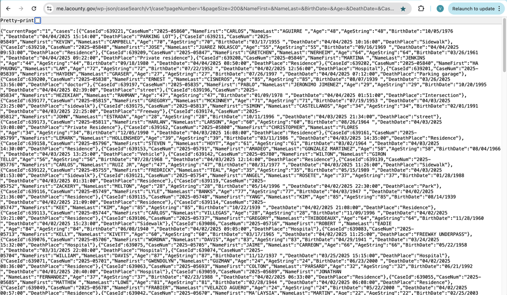

## More complications

- Your not-so-kind and impatient supervisor tells you to create a data pipeline specifically:
  - use Python to do it all so that your result is fully reproducible
  - drop the existing age variables they are not helpful and instead
  - RECALCULATE AGE using DeathDate and BirthDate (so your coworker’s advice on the existing age variables doesn’t matter)
  - and round the age result to one digit after the decimal
  - output the cleaned data to csv for distribution
  - AND omit birthdate from the output for privacy reasons

## The goal

- To help you understand the application of classes in Python
- And to have an understanding of object oriented programming
- So that when we move to the professional third party libraries like NumPy and Pandas
- You will be comfortable using them to the fullest
- And decide if/when you need classes

## Let’s load the data and take a look

- Everything starts with data and data will help guide the structure of our approach
- While JSON looks complex and messy, it really is orderly and simple

```python
import json

with open("case20250406.json", "r") as file:
        data = json.load(file)

print(f"The data type is: {type(data)}")  # should print <class 'list'>

# but it doesn't!  Figure out the structure by printing

print(f"Top-level keys:, {data.keys()}")

# Look at the first case
first_case = data["cases"][0] # data["cases"] is a list
print(first_case)
```

```
The data type is: <class 'dict'>
Top-level keys:, dict_keys(['currentPage', 'cases', 'startRecord', 'endRecord', 'totalPages', 'totalRecords'])
{'CaseId': 639297, 'CaseNum': '2025-05939', 'NameFirst': 'PIDIE', 'NameLast': 'LEWIS', 'Age': '39', 'AgeString': '39', 'BirthDate': '11/05/1985 ', 'DeathDate': '04/06/2025 14:49:00', 'DeathPlace': 'Residence'}
```

## Make the reading a little cleaner

- A great time to write a function
- Once we have figured out how to read the daily data dump
- We can write a little function so it reads data the same way every time:

```python
import json

def load_cases(filepath):
    with open(filepath, "r") as file:
        data = json.load(file)
    return data["cases"] # extracts the data

# so no matter what our data is named, it will be processed
raw_data1 = load_cases("case20250406.json")
raw_data2 = load_cases("case20250331.json")
raw_data3 = load_cases("case20250228.json")
raw_data4 = load_cases("case20250131.json")

# and examine
print(raw_data1[0])
print(raw_data1[-1])
print(raw_data2[0])
print(raw_data2[-1])
print(raw_data3[0])
print(raw_data3[-1])
print(raw_data4[0])
print(raw_data4[-1])
```

```
{'CaseId': 639297, 'CaseNum': '2025-05939', 'NameFirst': 'PIDIE', 'NameLast': 'LEWIS', 'Age': '39', 'AgeString': '39', 'BirthDate': '11/05/1985 ', 'DeathDate': '04/06/2025 14:49:00', 'DeathPlace': 'Residence'}
{'CaseId': 638982, 'CaseNum': '2025-05609', 'NameFirst': 'CARLOS ', 'NameLast': 'FERNANDEZ', 'Age': '29', 'AgeString': '29', 'BirthDate': '11/15/1995 ', 'DeathDate': '04/01/2025 08:30:00', 'DeathPlace': 'Pool'}
{'CaseId': 638970, 'CaseNum': '2025-05597', 'NameFirst': 'CHRISTINA', 'NameLast': 'ARTUKOVICH', 'Age': '38', 'AgeString': '38', 'BirthDate': '11/12/1986 ', 'DeathDate': '03/31/2025 23:48:00', 'DeathPlace': 'Residence'}
{'CaseId': 636392, 'CaseNum': '2025-03900', 'NameFirst': 'ELIJAH', 'NameLast': 'DAVENPORT', 'Age': '14', 'AgeString': '14', 'BirthDate': '01/14/2011 ', 'DeathDate': '03/01/2025 00:35:00', 'DeathPlace': 'Hospital'}
{'CaseId': 636391, 'CaseNum': '2025-03898', 'NameFirst': 'MARIZHYAN', 'NameLast': 'OGANESYAN', 'Age': '44', 'AgeString': '44', 'BirthDate': '09/03/1980 ', 'DeathDate': '02/28/2025 22:02:00', 'DeathPlace': 'Residence'}
{'CaseId': 634787, 'CaseNum': '2025-02151', 'NameFirst': 'DUSTIN', 'NameLast': 'YOUNTS', 'Age': '51', 'AgeString': '51', 'BirthDate': '10/12/1973 ', 'DeathDate': '02/01/2025 00:00:00', 'DeathPlace': 'RV'}
{'CaseId': 634786, 'CaseNum': '2025-02150', 'NameFirst': 'MARIO ', 'NameLast': 'GALDAMEZ COLOCHO', 'Age': '40', 'AgeString': '40', 'BirthDate': '02/24/1984 ', 'DeathDate': '01/31/2025 22:42:00', 'DeathPlace': 'Residence'}
{'CaseId': 632681, 'CaseNum': '2024-20529', 'NameFirst': 'PLACIDA', 'NameLast': 'MALDONADO', 'Age': '68', 'AgeString': '68', 'BirthDate': '02/03/1956 ', 'DeathDate': '12/31/2024 00:13:00', 'DeathPlace': 'Hospital'}
```

## Check for Understanding

- We have taken the first step and read the data
- Initially it was not very generalizable
- But once we figured it out, we could improve upon it

```python
from collections import Counter

death_places1 = [case.get("DeathPlace") for case in raw_data1]
death_places2 = [case.get("DeathPlace") for case in raw_data2]

# Count frequencies
freq_death_places1 = Counter(death_places1)
freq_death_places2 = Counter(death_places2)

# Print results
print(freq_death_places1)
print(freq_death_places2)
```

```
Counter({'Residence': 38, 'Hospital': 10, 'Sidewalk': 4, 'Street': 3, 'street': 2, 'sidewalk': 2, 'Private Residence': 2, 'Vehicle': 2, 'Garage': 1, 'Hillside': 1, 'Vacant Building': 1, 'Nursing Home': 1, 'Private driveway': 1, 'PARKING LOT': 1, 'Private residence': 1, 'Parking garage': 1, 'doctor':…
Counter({'Residence': 234, 'Hospital': 181, 'Street': 20, 'general': 17, 'Vehicle': 14, 'Sidewalk': 12, 'Private Residence': 11, 'Freeway': 9, 'Parking Lot': 8, '': 6, 'Alley': 5, 'Business': 4, 'SIDEWALK': 4, 'STREET': 4, 'Recreational Vehicle': 3, 'Yard': 3, 'VEHICLE': 3, 'PARKING LOT': 3, 'Parkin…
```

## Cleaning the data

- We were warned that the data has “issues” (e.g., inconsistent formatting)
- So this is a good time to work on cleaning data
- Strings can be cleaned with string methods like .strip(), .title(), .lower()
- Datetime can help us with the birth and death date

```python
def normalize_place(death_place):
    return death_place.strip().lower()

norm_death_places1 = Counter([normalize_place(i) for i in death_places1])

print(norm_death_places1)
```

```
Counter({'residence': 38, 'hospital': 10, 'sidewalk': 6, 'street': 5, 'private residence': 3, 'vehicle': 2, 'garage': 1, 'hillside': 1, 'vacant building': 1, 'nursing home': 1, 'private driveway': 1, 'parking lot': 1, 'parking garage': 1, 'doctor': 1, 'intersection': 1, 'freeway': 1, 'park': 1, 'fre…
```

## Inconsistent DateTime

```python
from datetime import datetime

def parse_date(date_str):
    for fmt in ("%m/%d/%Y %H:%M:%S", "%m/%d/%Y"):
        try:
            return datetime.strptime(date_str.strip(), fmt)
        except ValueError:
            continue
    raise ValueError(f"Unknown date format: {date_str}")
```

## Up to here

- We have yet to construct our own class
- We are just reading data and checking it and writing some helpers to clean it up
- In R, you might just stop here, in Python you “could” stop here, but your “supervisor” and “job” demand more because there is a daily routine involved, lots of repetition
- and now, Python beyond Jupyter

## Ready to define a class… but first

- What is a class?
  - It is a “blueprint” for a new object type in Python.
  - Python has built-in types like str, int, and list
  - We can make own custom data type for our data files for our “job”
  - Our custom class tells Python how to generate objects that represent individual cases from our JSON files.

## Some OOP vocabulary

- Instance: An instance is a specific, concrete realization of an object based on a class (like a blueprint)
- In object-oriented programming (OOP), a class defines a general structure, an instance is an actual object created from that class, with its own unique data.
- Instantiation: the process of creating an instance from a class. One calls the class to create an object in memory.

## Attribute Example

```python
import textwrap

my_range = range(0, 13)
attributes = dir(my_range)

# Join with spaces, wrap at 80 characters
print(textwrap.fill("  ".join(attributes), width=80))

# attribute of the range
print(my_range.start, my_range.step, my_range.stop)
```

```
__bool__  __class__  __contains__  __delattr__  __dir__  __doc__  __eq__
__format__  __ge__  __getattribute__  __getitem__  __getstate__  __gt__
__hash__  __init__  __init_subclass__  __iter__  __le__  __len__  __lt__  __ne__
__new__  __reduce__  __reduce_ex__  __repr__  __reversed__  __setattr__
__sizeof__  __str__  __subclasshook__  count  index  start  step  stop
0 1 13
```

## Methods Example

```python
my_list = ["UCLA", "UCSB", "UCI", "UCR", "UCSD"]
attributes = dir(my_list)

# Join with spaces, wrap at 80 characters
print(textwrap.fill("  ".join(attributes), width=80))

# list methods
my_list.append('UCSC') # one item
print(my_list)
my_list.extend(('UCD', 'UCB', 'UCM')) # an iterable
print(my_list)

# not a list method
len(my_list)
```

```
__add__  __class__  __class_getitem__  __contains__  __delattr__  __delitem__
__dir__  __doc__  __eq__  __format__  __ge__  __getattribute__  __getitem__
__getstate__  __gt__  __hash__  __iadd__  __imul__  __init__  __init_subclass__
__iter__  __le__  __len__  __lt__  __mul__  __ne__  __new__  __reduce__
__reduce_ex__  __repr__  __reversed__  __rmul__  __setattr__  __setitem__
__sizeof__  __str__  __subclasshook__  append  clear  copy  count  extend  index
insert  pop  remove  reverse  sort
['UCLA', 'UCSB', 'UCI', 'UCR', 'UCSD', 'UCSC']
['UCLA', 'UCSB', 'UCI', 'UCR', 'UCSD', 'UCSC', 'UCD', 'UCB', 'UCM']
```

```
9
```

## A class definition

- To start, we’ll keep all of the fields (age and age_string are useless given than your employer wants age recalculated from birth date and death date)
- We can drop them later on

```python
class Case:
    def __init__(self, case_id, case_num, first_name, last_name, age, age_string, birth_date, death_date, death_place):
        self.case_id = case_id
        self.case_num = case_num
        self.first_name = first_name
        self.last_name = last_name
        self.age = age
        self.age_string = age_string
        self.birth_date = birth_date
        self.death_date = death_date
        self.death_place = death_place
```

## Always start with `__init__`

```python
class Case:
    def __init__(self, case_id, case_num, first_name, last_name, age, age_string, birth_date, death_date, death_time, death_place):
```

- **init** is a special built-in method AKA a “dunder” method (short for “double underscore”)
- **init** is a constructor for a class. When you create an object of a class, the **init** method is automatically called to initialize the object’s attributes
- **init** always takes self as its first argument
- Python runs your **init** method and fills the object in with the values we are passing.
- The values are assigned to self.case_id, self.case_num, etc.,

## What is self?

```python
class Case:
    def __init__(self, case_id, case_num, first_name, last_name, age, age_string, birth_date, death_date, death_time, death_place):
        self.case_id = case_id
        self.case_num = case_num
        self.first_name = first_name
        self.last_name = last_name
```

- self is just a convention in Python — it refers to the specific object being created or acted upon
- Interpret it as “this object”
- When we specify self.first_name = first_name it just means “Use the value that is first_name and store it in this object’s first_name attribute.”
- Every method inside a class will be available in the instance must use self

## We can create an object

- This is instantiation, the act of generating an object from a class.
- The class is called Case

```python
cases = []
for case_data in raw_data1:
    case = Case(
        case_id=case_data["CaseId"],
        case_num=case_data["CaseNum"],
        first_name=case_data["NameFirst"],
        last_name=case_data["NameLast"],
        age=case_data["Age"],
        age_string=case_data["AgeString"],
        birth_date=case_data["BirthDate"],
        death_date=case_data["DeathDate"],
        death_place=case_data["DeathPlace"]
    )
    cases.append(case)

#for c in cases:
#    print(c)

for c in cases: # only Python understands this
    print(c)
    break
```

```
<__main__.Case object at 0x12e937e00>
```

## A class definition modified

- The magic (dunder) **str** method can provide a human readable format

```python
class Case:
    def __init__(self, case_id, case_num, first_name, last_name, age, age_string, birth_date, death_date, death_place):
        self.case_id = case_id
        self.case_num = case_num
        self.first_name = first_name
        self.last_name = last_name
        self.age = age
        self.age_string = age_string
        self.birth_date = birth_date
        self.death_date = death_date
        self.death_place = death_place

    def full_name(self):
        return f"{self.first_name.title()} {self.last_name.title()}"

    def __str__(self):
        return f"{self.full_name()} (Case #{self.case_num}) Birth: {self.birth_date}"
```

## Object from modified class with **str**

```python
cases = []
for case_data in raw_data1:
    case = Case(
        case_id=case_data["CaseId"],
        case_num=case_data["CaseNum"],
        first_name=case_data["NameFirst"],
        last_name=case_data["NameLast"],
        age=case_data["Age"],
        age_string=case_data["AgeString"],
        birth_date=case_data["BirthDate"],
        death_date=case_data["DeathDate"],
        death_place=case_data["DeathPlace"]
    )
    cases.append(case)

for c in cases:
    print(c)
    break
```

```
Pidie Lewis (Case #2025-05939) Birth: 11/05/1985
```

## What might this look like in reality?

- You would have a separate file (.py) for your class definition (case.py)
- A script for input and output of the data for this problem (input_output.py)
- A script for the utlities, functions that could be used in other situations (utils.py)
- A script for directing the whole process and instantiating the class (main.py)
- The data would be stored in a specific location (a data folder)
- The output data set would be written to a different location (an output folder)

## Running main.py

- A script for directing the whole process and instantiating the class (main.py)
- This would actually be written nearly last or alongside the others

```python
# main.py
from input_output import load_cases, parse_cases, write_cases_to_csv

input_data_files = ["data/case20250331.json", "data/case20250406.json"]
output_data_file = "data/output/cases.csv"
def main():
    files = input_data_files
    all_cases = []

    for file in files:
        raw_data = load_cases(file)
        cases = parse_cases(raw_data)
        all_cases.extend(cases)

    for case in all_cases[:6]:  # Preview first few
        print(case)

    write_cases_to_csv(all_cases, output_data_file)

if __name__ == "__main__":
    main()
```

## Main.py imports input_output.py

- A script for input and output of the data for this problem (input_output.py)
- input_output.py imports our Case function from case.py

```python
# input_output.py
# This module handles the input and output of case data.
import json
import csv
from case import Case

def load_cases(filepath):
    with open(filepath, "r") as file:
        data = json.load(file)
    return data.get("cases", [])

def parse_cases(data):
    return [
        Case(
            case_id=item["CaseId"],
            case_num=item["CaseNum"],
            first_name=item["NameFirst"],
            last_name=item["NameLast"],
            birth_date=item["BirthDate"],
            death_date=item["DeathDate"],
            death_place=item["DeathPlace"]
        )
        for item in data
    ]

def write_cases_to_csv(cases, out_path):
    fieldnames = ["CaseId", "CaseNum", "FirstName", "LastName", "DeathDate", "DeathAge", "DeathPlace"]
    with open(out_path, "w", newline="") as csvfile:
        writer = csv.DictWriter(csvfile, fieldnames=fieldnames)
        writer.writeheader()
        for case in cases:
            writer.writerow(case.to_dict())
```

## input_output.py imports case.py

- case.py contains the class definition where the data and useful methods come together
- case.py imports utils.py which helps us with the dates and places

```python
# case.py

from utils import parse_date, normalize_place

class Case:
    def __init__(self, case_id, case_num, first_name, last_name, birth_date, death_date, death_place):
        self.case_id = case_id
        self.case_num = case_num
        self.first_name = first_name.strip()
        self.last_name = last_name.strip()
        self.birth_date = birth_date.strip()
        self.death_date = death_date.strip()
        self.death_place = normalize_place(death_place)

        self.birth = parse_date(self.birth_date)
        self.death = parse_date(self.death_date)
        self.death_hour = self.death.hour

    def age_in_days(self):
        return (self.death - self.birth).days

    def age_in_years(self):
        return round(self.age_in_days() / 365.25, 1)

    def full_name(self):
        return f"{self.first_name.title()} {self.last_name.title()}"

    def to_dict(self):
        return {
            "CaseId": self.case_id,
            "CaseNum": self.case_num,
            "FirstName": self.first_name.title(),
            "LastName": self.last_name.title(),
            "DeathDate": self.death_date,
            "DeathAge": self.age_in_years(),
            "DeathPlace": self.death_place
        }

    def __str__(self):
        return (
           f"{self.full_name():<20} | "
           f"Case #{self.case_num:<10} | "
           f"DOD: {self.death_date} | "
           f"Age: {self.age_in_years():>4} yrs"
        )
```

## case.py imports utils.py

```python
# utils.py

from datetime import datetime

def parse_date(date_str):
    for fmt in ("%m/%d/%Y %H:%M:%S", "%m/%d/%Y"):
        try:
            return datetime.strptime(date_str.strip(), fmt)
        except ValueError:
            continue
    raise ValueError(f"Unknown date format: {date_str}")

def normalize_place(death_place):
    return death_place.strip().lower()
```

## Closing Week 3

- There is a continuum of the uses of Python
- From constructing notebooks like Jupyter
- To writing scripts (.py) for production
- And everything in-between and also points beyond the edges here
- Where do you fit?

## Next Week

- NumPy - the foundational package for scientific computing in Python
  - Pandas: built atop NumPy arrays
  - Matplotlib: Plots use NumPy arrays
  - scikit-learn: NumPy arrays as input
- NumPy is vectorized